# Machine Learning Write-up

## I. Introduction

This document comprises of the first component of Coursera online course Pratical Machine Learning’s course project: Writeup. In this document, I outline the major steps I have taken to build the model for the data analysis and the motivations behind the steps.

The focus of analysis has been put on whether and how to maximize model performance while minimizing the use of training data and features available.

## II. Dataset

The training and testing data are provided in this course. It has to be noted that the testing data only contains 20 samples, too small to be used to evaluate the model. Thus, it is only used for the purpose of unit test for the model, which comprises the second component of this project.

The training and testing data are below, which are provided by http://groupware.les.inf.puc-rio.br/har:

https://d396qusza40orc.cloudfront.net/predmachlearn/pml-training.csv

https://d396qusza40orc.cloudfront.net/predmachlearn/pml-testing.csv

## III. Data Preprocessing

**Reading and Examining Data**

```r
data <- read.csv("pml-training.csv")
```

The ‘str(data)’ indicates that this data set has 19622 observations of 160 variables. The training data is in a good size and the dimension is pretty high. In particular, it shows that many columns are full of NA values. Because of this, the first intuition is to remove those columns that contains NAs, as well as empty cells. To do this:

**Pruning and Examining Data**

```r
data[data==""] <- NA
data = data[sapply(data, function(x) all(complete.cases(x)))]
str(data)
```

```
## 'data.frame':    19622 obs. of  60 variables:
##  $ X                   : int  1 2 3 4 5 6 7 8 9 10 ...
##  $ user_name           : Factor w/ 6 levels "adelmo","carlitos",..: 2 2 2 2 2 2 2 2 2 2 ...
##  $ raw_timestamp_part_1: int  1323084231 1323084231 1323084231 1323084232 1323084232 1323084232 1323084232 1323084232 1323084232 1323084232 ...
##  $ raw_timestamp_part_2: int  788290 808298 820366 120339 196328 304277 368296 440390 484323 484434 ...
##  $ cvtd_timestamp      : Factor w/ 20 levels "2/12/2011 13:32",..: 15 15 15 15 15 15 15 15 15 15 ...
##  $ new_window          : Factor w/ 2 levels "no","yes": 1 1 1 1 1 1 1 1 1 1 ...
##  $ num_window          : int  11 11 11 12 12 12 12 12 12 12 ...
##  $ roll_belt           : num  1.41 1.41 1.42 1.48 1.48 1.45 1.42 1.42 1.43 1.45 ...
##  $ pitch_belt          : num  8.07 8.07 8.07 8.05 8.07 8.06 8.09 8.13 8.16 8.17 ...
##  $ yaw_belt            : num  -94.4 -94.4 -94.4 -94.4 -94.4 -94.4 -94.4 -94.4 -94.4 -94.4 ...
##  $ total_accel_belt    : int  3 3 3 3 3 3 3 3 3 3 ...
##  $ gyros_belt_x        : num  0 0.02 0 0.02 0.02 0.02 0.02 0.02 0.02 0.03 ...
##  $ gyros_belt_y        : num  0 0 0 0 0.02 0 0 0 0 0 ...
##  $ gyros_belt_z        : num  -0.02 -0.02 -0.02 -0.03 -0.02 -0.02 -0.02 -0.02 -0.02 0 ...
```

[output cut: 46 more lines]

The removal of these NAs and empty values reduces the dimension from 160 to 60, cutting it by more than half. A quick look at the remaining variables reveals that, the first few variables may be good candidates for further removal for the reasons: X: values runs from 1 to 19622, basically a serial number or row number, which shouldn’t be used in training. user_name: if used, the trained model will be depending on individidual participants raw_timestamp_part_1, raw_timestamp_part_2, cvtd_timestamp: Not clear the exact meaning of these features, but they are time related values

Instead of removing these variables immedicately and pursing other preprocessing techniques, let’s build a first model and see how it works, and we can start from there based on the result. The next step is to partition the training data. Should we partition it into training, testing and validating sets, or training and testing sets only? Given it has a total of 19622 samples, which is a good size, it may be a good idea to produce three sets, rather than two, so that we have a completely unseen data set used to validate the eventual model, which won’t be used for model training and tuning in any way. The Out of Sample error can be eventually evaluated on the validating set.

A good pratice is to split the data with a 6:2:2 ratio. To do that:

**Include Data**

```r
library(caret)
```

**Data Partition**

```r
inTrain <- createDataPartition(y=data$classe,p=0.6,list=FALSE)
training <- data[inTrain,]
testingTemp <- data[-inTrain,]
inTest <- createDataPartition(y=testingTemp$classe,p=0.5,list=FALSE)
testing <- testingTemp[inTest,]
validating <- testingTemp[-inTest,]
```

Now, check the dimension of the splits to make sure it’s right.

**Check Dimensions**

```r
dim(training); dim(testing); dim(validating)
```

```
## [1] 11776    60
```

```
## [1] 3923   60
```

```
## [1] 3923   60
```

## IV. Initial Training and Evaluation

Now, we need to train and evalute the model. What classification model should I try and choose? Random Forest is my first consideration, for two reasons. First, this week’s lecture has been talking about classificaiton with trees, and RF is generally considered as one of the best performing ML algorithms in many classification tasks; second, the authors in the paper who provided the original data also mentioned they were using random forest and got good results.

For convenience, I choose to use the “train” and “confusionMatrix” functions available in caret package. Also, since I need to run multiple experiments of training and evaluation, I write a function to do the task, so that it can be reused later.

A function called “trainer” is defined, which takes as parameters four arguments: * training: the training data as a dataframe created through the data partition steps * testing: the testing (or validating) data as a dataframe created through the data partition steps * trMethod: the trainControl parameter, i.e. method=“oob” or method=“cv” number=“5” * trModel: the classification model to be chosen, i.e. “RF” or “svmlinear”

```r
trainer <- function(training, testing, trMethod, trModel){

    # training and evaluation
    trControl = trainControl(method=trMethod)
    modelFit <- train(training$classe ~ ., method=trModel, trControl=trControl, data=training)
    confMatrix <- confusionMatrix(testing$classe,predict(modelFit,testing))

    # model inspection
    gbmImp <- varImp(modelFit, scale = FALSE)
    importance <- gbmImp[[1]]
    top20RowNames <- rownames(importance)[order(importance,decreasing=TRUE)][1:20]

    # return values
    list(modelFit, confMatrix, gbmImp, importance, top20RowNames)
}
```

The function retuns five values in a list: * modelFit: the resulting model * confMatrix: confusionMatrix to display accuracy matrics * gbmImp: the variable importance object, obtained through ‘varImp’ method * importance: the object which contains importance values of each variable in the model * top20RowNames: since there are 60 features in total, this value return the top 20 varialbes which are most important

Now run the trainer and check the confusion matrix:

```r
# The resampling method selects "oob" for random forest here.
output <- trainer(training, testing, "oob", "rf")
confMatrix <- output[[2]]
gbmImp <- output[[3]]
confMatrix
```

```
## Confusion Matrix and Statistics
##
##           Reference
## Prediction    A    B    C    D    E
##          A 1116    0    0    0    0
##          B    0  759    0    0    0
##          C    0    0  684    0    0
##          D    0    0    0  643    0
##          E    0    0    0    0  721
##
## Overall Statistics
##
##                Accuracy : 1
##                  95% CI : (0.999, 1)
##     No Information Rate : 0.284
##     P-Value [Acc > NIR] : <2e-16
##
##                   Kappa : 1
##  Mcnemar's Test P-Value : NA
##
## Statistics by Class:
##
##                      Class: A Class: B Class: C Class: D Class: E
## Sensitivity             1.000    1.000    1.000    1.000    1.000
## Specificity             1.000    1.000    1.000    1.000    1.000
## Pos Pred Value          1.000    1.000    1.000    1.000    1.000
## Neg Pred Value          1.000    1.000    1.000    1.000    1.000
## Prevalence              0.284    0.193    0.174    0.164    0.184
## Detection Rate          0.284    0.193    0.174    0.164    0.184
## Detection Prevalence    0.284    0.193    0.174    0.164    0.184
## Balanced Accuracy       1.000    1.000    1.000    1.000    1.000
```

Now, the confMatrix shows that all metrics are 1, which indicates it’s a perfect model. However, this “too good to be true” scenario can hardly occur in real world. One guess is that this model is biased toward one or a few particular variables, which contribute most to the model in this training set. However, these variables won’t contribute to a more generalized model formation, when another set of data is collected.

To inspect variable importance, I plot top 20 variables with the gbmImp object, returned by trainer.

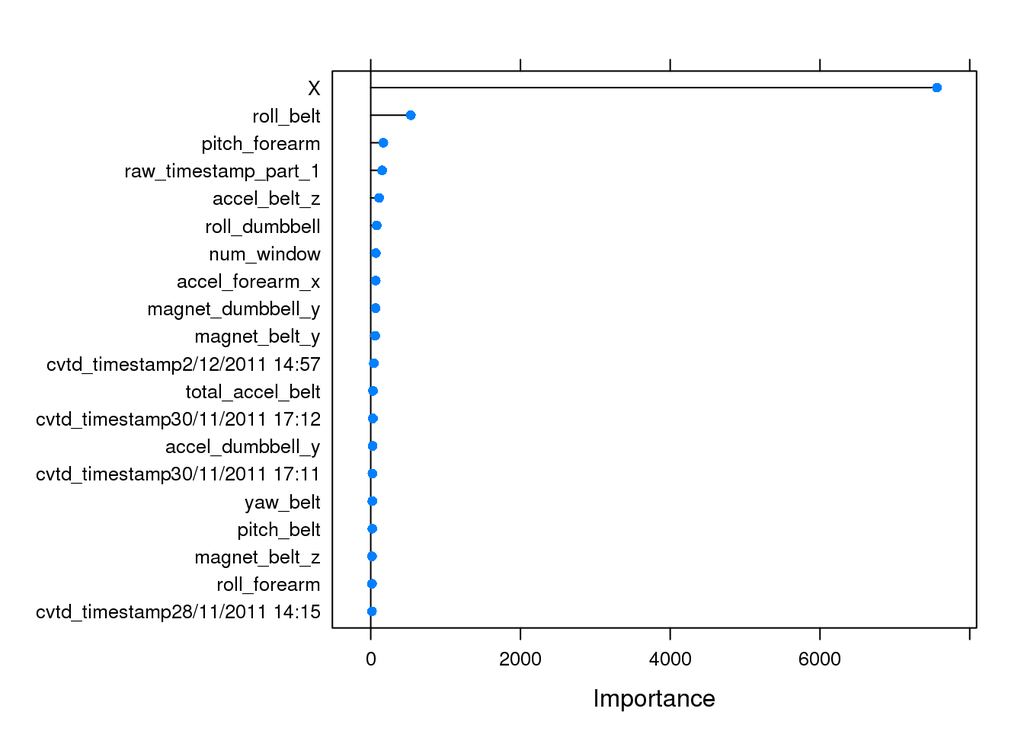

```r
plot(gbmImp, top=20)
```

## V. Second Training and Evaluation with Feature Selection

To remove column 1-7:

```r
training <- training[,8:60]
testing <- testing[,8:60]
validating <- validating[,8:60]

dim(training); dim(testing); dim(validating)
```

```
## [1] 11776    53
```

```
## [1] 3923   53
```

```
## [1] 3923   53
```

Train and evaluate the model again. To measure the time needed for the training, I added the function system.time() to record the training time (in seconds) needed, since training time is also an important consideration in building and evaluating a model.

```r
# convert the time from seconds to minutes by dividing system time by 60
system.time(output <- trainer(training, testing, "oob", "rf")) / 60
```

```
##    user  system elapsed
## 2.04175 0.00355 2.04522
```

```r
confMatrix <- output[[2]]
gbmImp <- output[[3]]
confMatrix
```

```
## Confusion Matrix and Statistics
##
##           Reference
## Prediction    A    B    C    D    E
##          A 1116    0    0    0    0
##          B    3  756    0    0    0
##          C    0    4  679    1    0
##          D    0    0   10  632    1
##          E    0    0    0    1  720
##
## Overall Statistics
##
##                Accuracy : 0.995
##                  95% CI : (0.992, 0.997)
##     No Information Rate : 0.285
##     P-Value [Acc > NIR] : <2e-16
##
##                   Kappa : 0.994
##  Mcnemar's Test P-Value : NA
##
## Statistics by Class:
##
##                      Class: A Class: B Class: C Class: D Class: E
## Sensitivity             0.997    0.995    0.985    0.997    0.999
## Specificity             1.000    0.999    0.998    0.997    1.000
## Pos Pred Value          1.000    0.996    0.993    0.983    0.999
## Neg Pred Value          0.999    0.999    0.997    0.999    1.000
## Prevalence              0.285    0.194    0.176    0.162    0.184
## Detection Rate          0.284    0.193    0.173    0.161    0.184
## Detection Prevalence    0.284    0.193    0.174    0.164    0.184
## Balanced Accuracy       0.999    0.997    0.992    0.997    0.999
```

After pruning the irrevalent features, the model still achieves a high accuracy of > 99%, as seen from the confusion matrix, and the training time is < 4 minutes, which is very acceptable. By now, I think a good model has been built for this prediction task, since the model performance is high and training time is short.

Now, vadidate the model using validating set:

```r
confMatrix <- confusionMatrix(validating$classe,predict(output[[1]],validating))
print(confMatrix)
```

```
## Confusion Matrix and Statistics
##
##           Reference
## Prediction    A    B    C    D    E
##          A 1116    0    0    0    0
##          B    7  752    0    0    0
##          C    0    5  678    1    0
##          D    0    0   19  623    1
##          E    0    0    1    4  716
##
## Overall Statistics
##
##                Accuracy : 0.99
##                  95% CI : (0.987, 0.993)
##     No Information Rate : 0.286
##     P-Value [Acc > NIR] : <2e-16
##
##                   Kappa : 0.988
##  Mcnemar's Test P-Value : NA
##
## Statistics by Class:
##
##                      Class: A Class: B Class: C Class: D Class: E
## Sensitivity             0.994    0.993    0.971    0.992    0.999
## Specificity             1.000    0.998    0.998    0.994    0.998
## Pos Pred Value          1.000    0.991    0.991    0.969    0.993
## Neg Pred Value          0.998    0.998    0.994    0.998    1.000
## Prevalence              0.286    0.193    0.178    0.160    0.183
## Detection Rate          0.284    0.192    0.173    0.159    0.183
## Detection Prevalence    0.284    0.193    0.174    0.164    0.184
## Balanced Accuracy       0.997    0.996    0.985    0.993    0.999
```

Before concluding this project, I would like to explore a bit more with the data and training. In particular, I would like to know how the size of training data and features impact model performance and training time. It would be great if same or similar performance can be achieved with reduced training data and features. Section VI and VII contributes to the analysis of these two factors.

## VI. Learning Curve with respect to Training Data Size

```r
learningCurve <- function(training,testing){

    n = 1;
    r = 0;
    # Create a matrix to store trainingFactor, training time and model accuracy, used for learning curve plot.
    lcMatrix = matrix(nrow=16,ncol=3,dimnames=list(NULL,c("trainingSize", "trainingTime", "accuracy")))
    for(n in 1:16){
        r = r + 0.0625
        inTrain <- createDataPartition(y=training$classe,p=r,list=FALSE)
        smallTraining <- training[inTrain,]
        print(dim(smallTraining)); print(dim(testing))
        trainingTime <- system.time(output<-trainer(smallTraining,testing,"oob", "rf"))[3]/60
        confMatrix <- output[[2]]
        overall.accuracy <- round(confMatrix$overall['Accuracy'],digits=3)
        print(overall.accuracy)
        lcMatrix[n,] <- c(dim(smallTraining)[1], round(trainingTime,digits=3), overall.accuracy)
    }

    lcMatrix
}
```

Now call function learningCurve to plot the learning curve.

```r
require(ggplot2)
require(reshape2)
lcMatrix <- learningCurve(training,testing)
```

```
## [1] 739  53
## [1] 3923   53
## Accuracy
##    0.881
## [1] 1474   53
## [1] 3923   53
## Accuracy
##    0.932
## [1] 2210   53
## [1] 3923   53
## Accuracy
##    0.953
## [1] 2946   53
## [1] 3923   53
## Accuracy
##    0.964
## [1] 3683   53
## [1] 3923   53
## Accuracy
##    0.972
## [1] 4418   53
## [1] 3923   53
## Accuracy
##    0.977
## [1] 5155   53
## [1] 3923   53
## Accuracy
##    0.983
## [1] 5889   53
## [1] 3923   53
## Accuracy
##    0.983
## [1] 6626   53
## [1] 3923   53
## Accuracy
##    0.985
## [1] 7363   53
## [1] 3923   53
## Accuracy
##    0.985
```

[output cut: 9 more lines]

```
## [1] 3923   53
## Accuracy
##    0.989
## [1] 10307    53
## [1] 3923   53
## Accuracy
##    0.989
## [1] 11042    53
## [1] 3923   53
## Accuracy
##    0.993
## [1] 11771    53
## [1] 3923   53
## Accuracy
##    0.994
```

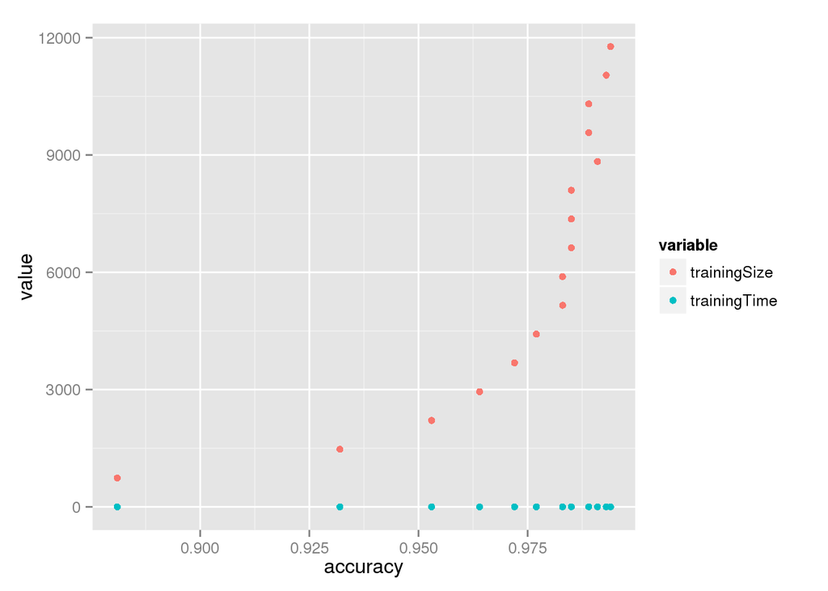

```r
ggplot(melt(as.data.frame(lcMatrix), id="accuracy"),
        aes(x = accuracy, y = value, color = variable)) +
        geom_point()
```

```r
oneFeatureTraining <- function(training){

    n = 1;
    iteration = dim(training)[2]
    type = training[,"classe"]
    print(dim(training));

    # Create a matrix to store trainingFactor, training time and model accuracy, used for learning curve plot.
    lcMatrix = matrix(nrow=iteration,ncol=2,dimnames=list(NULL,c("featureNo", "accuracy")))
    for(n in 1:iteration){
        smallTraining <- as.data.frame(training[,n])
        smallTraining["classe"] <- type

        trControl = trainControl(method="oob")
        modelFit <- train(training$classe ~ ., method="rf", trControl=trControl, data=training)
        overall.accuracy = round(max(modelFit["results"][[1]][,"Accuracy"]),digits=3)
        lcMatrix[n,] <- c(n, overall.accuracy)
    }
    lcMatrix
}
```

```r
inTrain <- createDataPartition(y=training$classe,p=0.3,list=FALSE)
smallTraining <- training[inTrain,]
lcMatrix <- oneFeatureTraining(smallTraining)
```

```
## [1] 3535   53
```

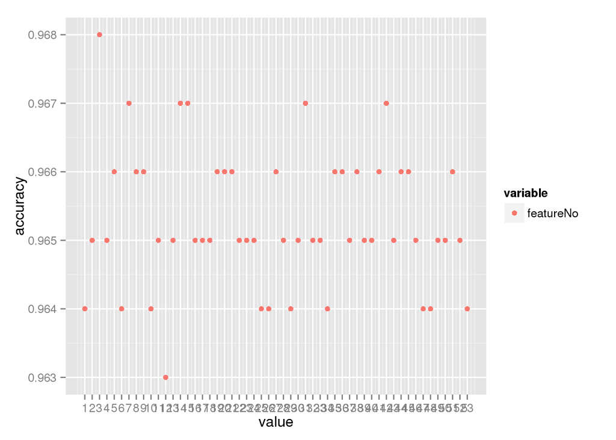

```r
ggplot(melt(as.data.frame(lcMatrix), id="accuracy"),
        aes(x = value, y = accuracy, color = variable)) +
        geom_point() + scale_x_continuous(breaks=1:dim(smallTraining)[2])
```